# Week 7

Peter Dolan

10/4/2019

## Overview

We covered likelihood:

- One sample from a single distribution
- Multiple samples from the same distribution
- Drawing the likelihood curve for a family of distributions
- Parameter values that leads to maximum likelihood estimate (MLE)
- Switching to log likelihood

Generalized Linear Models:

- Vocabulary
  - Link function
  - Systematic Component
  - Random Component
- Likelihood curve for model parameters (in a GLM context)
- Curve of best fit uses MLE
- Example
  - Crab Satellites (Poisson)
  - Crab Satellites (Negative Binomial)
- Discussion of Over dispersion
- Negative Binomial Distribution
  - Definition
  - Multiple parameterizations

## Likelihood

We have been discussing the logistic regression and talked *a bit* about its relationship with the $\textrm{binomial}$ distribution. Consider a typical statement from an Introductory Statistics course where the random variable $X$ has a $\textrm{Binom}(n,p)$ distribution:

$$\textrm{P}(X=k) = {n \choose k}p^k(1-p)^{n-k}$$
Another way to write that probability distribution reinforces the dependency of the probability on the **parameters** of the **binomial family**: namely $n$ and $p$:

$$\textrm{P}(X=k\big|n,p) = {n \choose k}p^k(1-p)^{n-k}$$

Notice that **given** the values of $n$ and $p$, the function on the right truly is a probability distribution.

Now consider a situation in which you have observed $n$ cars passing through an intersection and kept track of the number , $k$, that actually came to a complete stop. Assuming that the assumptions for a binomial distribution are satisfied, which one do you choose to use to model the observed situation? In this situation $n$ is locked down solidly by the observations… so the only parameter with any wiggle room is $p$.

Notice that as we consider different values of $p$, we get different probability distributions. Under some of those distributions the observed value of $k$ will be more likely than under others.

One approach to picking a distribution is find the value of $p$ which makes the observed $X=k$ the **most likely**.

So we have done something quite interesting. We have turned the question on its head. Let’s call this function the **likelihood** function:

$$\mathcal{L}(p) = {n \choose k}p^k(1-p)^{n-k}$$

Notice that the right-hand side is **identical** to the right-hand side for the $\textrm{P}(X=k)$. But our intent is different. When we are considering the binomial distribution, we consider $n$ and $p$ to be **fixed** and see what happens when the value of $k$ is varied. When we are consider the the **likelihood**. We consider $k$ and $n$ to be fixed and see what happens when $p$ is varied. This is **not** a probability function because the area under the curve made by all possible values of $p$ does not equal 1. Consider a situation where $n=10$ and $k=3$:

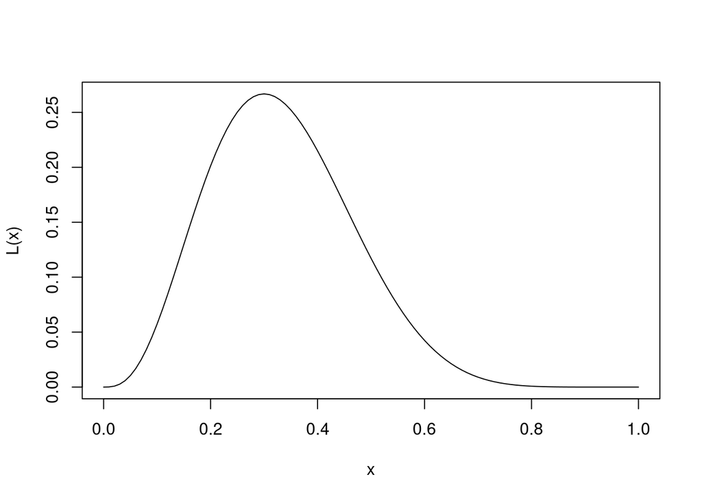

```r
l=function(p){choose(n,k)*p^k*(1-p)^(n-k)}
n=10
k=3
L=Vectorize(l)
curve(L(x),0,1)
```

Let’s approximate the area:

```r
n=100
x.i=seq(0,1,length.out=n) #n equal sized chunks from 0 to 1
y.i=l(x.i[-n]) #left hand rule
delta.x=x.i[-1]-x.i[-n]
sum(delta.x*y.i)
```

```
## [1] 0.009912085
```

So we see this is definitely **not** a probability distribution. Let’s suppose we didn’t know the maximum value. Let’s build a (very inefficient) function whose job is to find a local maximum. What features would we like this function to have?

1. We should provide the function to be optimized
2. We should provide the range to examine
3. We should provide a tolerance that determines when we are *close enough* to be happy.

```r
maximizer=function(f,a,b,tolerance=0.01){
  x=seq(a,b,length.out=1000)
  F=Vectorize(f) #Just in case f isn't already vector-capable
  best=which.max(F(x))
  if(best==1 | best==length(x)){return(best)} # maximum occurs at boundary
  lower=x[best-1]
  upper=x[best+1]
  if(abs(upper-lower)<tolerance){return(x[best])} #Ensures recursion eventually stops
  return(maximizer(f,x[best-1],x[best+1],tolerance))
}
```

Now we can estimate the value of $p$ that produces the maximum likelihood:

```r
maximizer(l,0,1,0.0001)
```

```
## [1] 0.03000097
```

For those of you that have taken calculus, we could bypass the numeric approximations:

$$\begin{aligned}
\textrm{P}(X=k))&={n \choose k}p^k(1-p)^{n-k}\\
\mathcal{L}(p)&={n \choose k}p^k(1-p)^{n-k}\\
\frac{\textrm{d}\mathcal{L}(p)}{\textrm{d}p}&={n \choose k}\biggl(kp^{k-1}(1-p)^{n-k} - (n-k)p^k(1-p)^{n-k=1}\biggr)\\
&={n \choose k}p^{k-1}(1-p)^{n-k-1}\biggl(k(1-p) - (n-k)p\biggr)\\
&={n \choose k}p^{k-1}(1-p)^{n-k-1}\biggl(k-kp -np+kp \biggr)\\
&={n \choose k}p^{k-1}(1-p)^{n-k-1}\biggl(k-np\biggr)\\
\end{aligned}$$
Now to find the value of $p$ that maximizes $\mathcal{L}(p)$ we need the derivative to be set to 0. Notice that one solution to this equation is when $k-np=0$. But that simplifies to $p=\frac{k}{n}$. In other words, the value of $p$ that is **most likely** (for an observed value of $k$) is the same as the sample proportion $\frac{k}{n}$.

Wow! a lot of math to say something that probably seems pretty obvious. But the same idea can be applied to more complicated likelihood equations… **and** this places very few restrictions on the variables.

So, in summary, the Maximum Likelihood technique will find the parameters for the family of distributions that is most consistent with the data. (Whether you have chosen a good family to model your data is a different question entirely– and it is not one that is answered by this technique)

This kind of parameter fitting is the basis for all of the GLM approaches. Let’s identify a few key components. We’ll let $\mu_i$ denote the **actual** mean of the distribution from which the response value $y_i$ was drawn. We let $x_ki$ denote the **value** of variable $X_k$ for observation $i$

Then we have a relationship interconnecting a linear predictor on the right with a transformed $\mu_i$ on the left:

$$g(\mu_i) = b_0 + b_1 x_{1i}+ b_2 x_{2i} + \cdots + \textrm{error}$$

The values of $y_i$ (conditioned on the explanatories) are called the **random component**.

The linear model on the right, $b_0 + b_1X_1 + b_2 X_2 + \cdots + b_p X_p$ is called the **systematic component**. It’s common to use $\eta$ to represet the output. And then have (simplifying notation a bit to make the relationships easier to follow):

$$\begin{aligned}
\eta &= b_0 + b_1X_1 + b_2 X_2 + \cdots + b_p X_p\\
g(\mu) &= \eta\\
\textrm{P}(Y|X) &= \textrm{Some parameterized family that depends upon }\mu
\end{aligned}$$

The **family** of the random component distribution determines the type of Regression:

| Style | Family | Link function |
| --- | --- | --- |
| OLS | Normal | $\textrm{Identity}$ |
| Logistic | Binomial | $\textrm{logit}$ |
| Poisson | Poisson | $\ln()$ |
| Negative Binomial | Negative Binomial | $\ln()$ |

**Note:** I’m including a typical link functions. **Other Link functions are possible!**. For example the **probit** link function is also fairly common in logistic regression. (I’m not going to go into those details however.)

## Poisson Distribution

We loaded some Crab data from a 1996 Study on female crabs and the number of male “satellites” following them:

```
Color: 1: light medium
       2: medium
       3: dark medium
       4: dark
Spine Condition
       1: Both good
       2: One worn or broken
       3: Both worn or broken
Carapace Width (in cm)
Weight in kilograms
Number of Satellites (aka-- male's grouped around female hoping to mate)

Data from Jane Brockmann, Zoology Department University of Floriday from Etcholog 102: 1-21, 1996
```

Let’s load it and look at it:

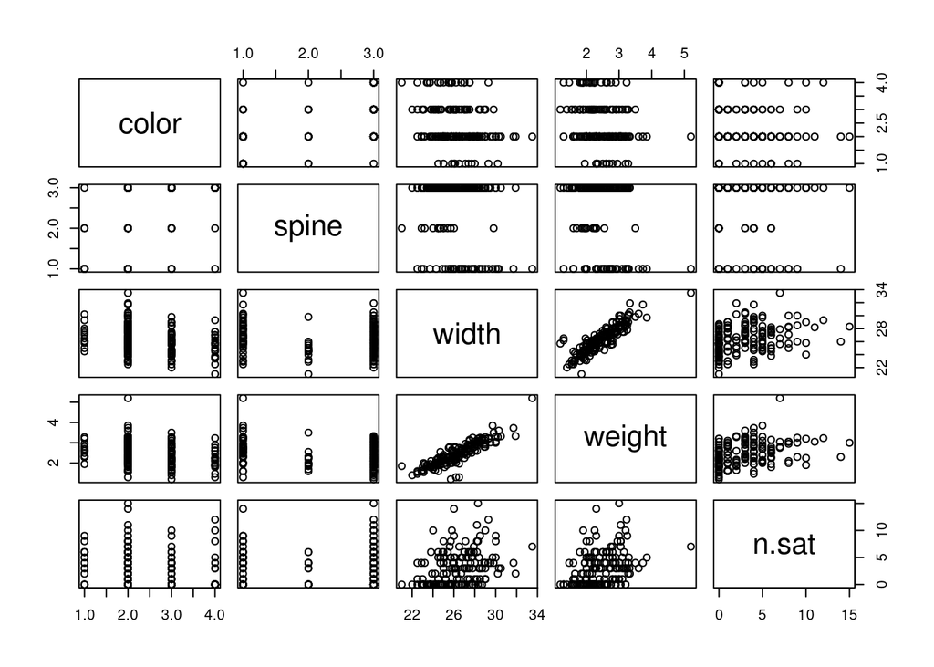

```r
crab=read.table("https://personal.psu.edu/abs12/stat504/online/07_poisson/graphics/crab.txt")
colnames(crab)=c("obs","color","spine","width","weight","n.sat")
crab=crab[,-1] #Drop the observation column
pairs(crab)
```

We did some exploratory data analysis and several interesting relationships were described in class.

Here are some examples

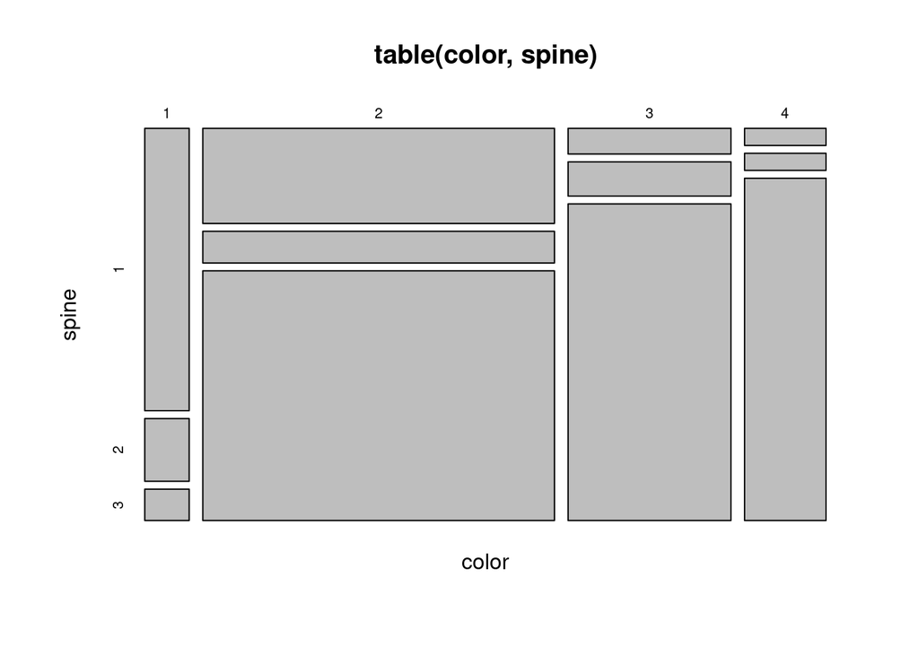

```r
with(crab,{plot(table(color,spine))}) #Obvious relation... suggests age to me
```

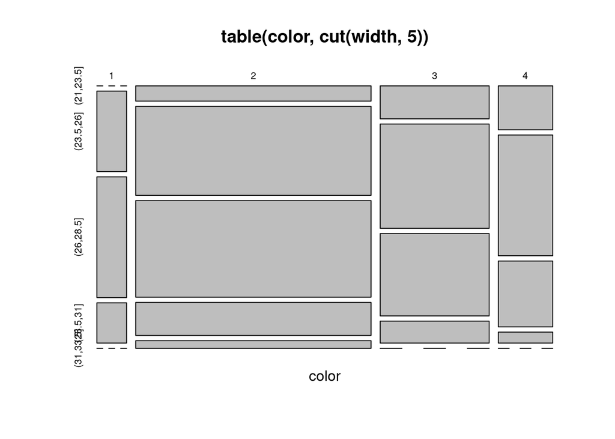

```r
#As color gets darker spine conditions gets worse
with(crab,plot(table(color,cut(width,5)))) #That's not consistent with age.. I would have thought
```

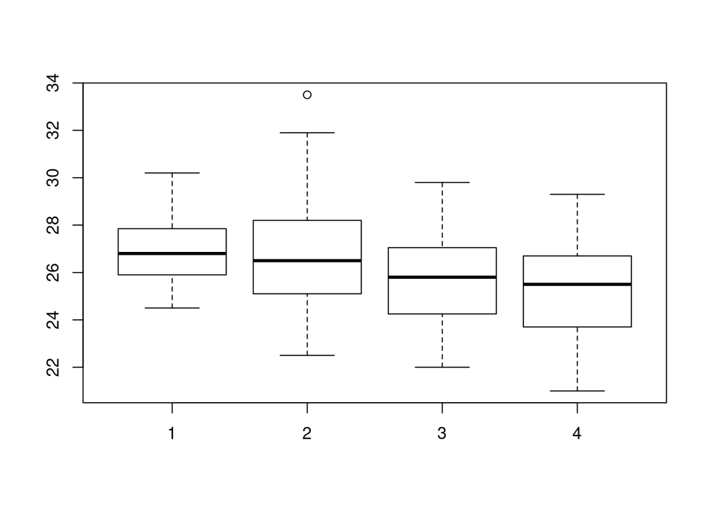

```r
# carapace width was associated with age... but small
with(crab,boxplot(width~color))
```

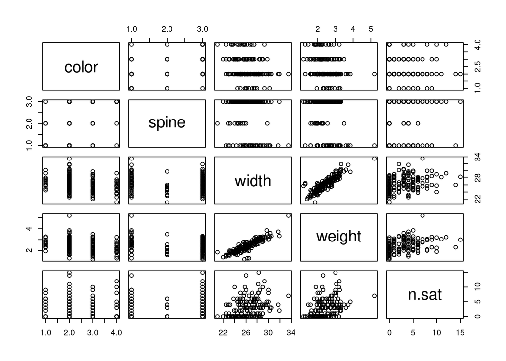

```r
# That highlights that it's the inverse of what I would have expected
pairs(crab)
```

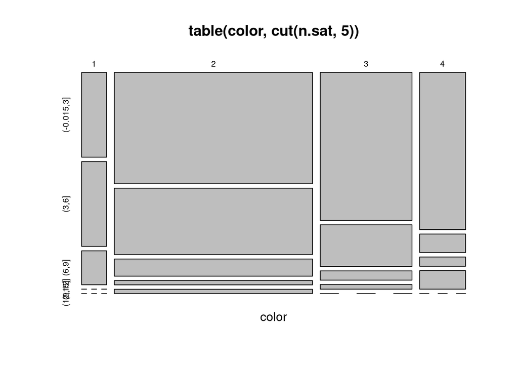

```r
# width and weight are, reasonably correlated
with(crab,plot(table(color,cut(n.sat,5))))
```

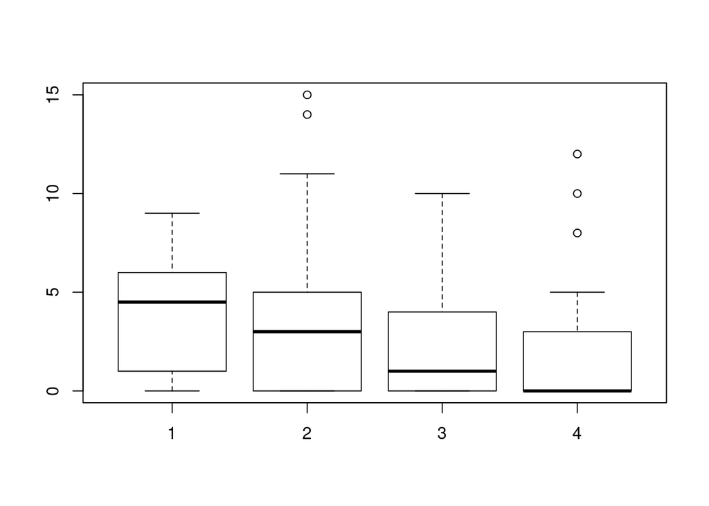

```
## $stats
##      [,1] [,2] [,3] [,4]
## [1,]  0.0    0    0    0
## [2,]  1.0    0    0    0
## [3,]  4.5    3    1    0
## [4,]  6.0    5    4    3
## [5,]  9.0   11   10    5
## attr(,"class")
##         1
## "integer"
##
## $n
## [1] 12 95 44 22
##
## $conf
##          [,1]     [,2]       [,3]      [,4]
## [1,] 2.219466 2.189477 0.04722415 -1.010571
## [2,] 6.780534 3.810523 1.95277585  1.010571
##
## $out
## [1] 14 15 10  8 12
##
## $group
## [1] 2 2 4 4 4
##
## $names
## [1] "1" "2" "3" "4"
```

```r
with(crab,(boxplot(n.sat~color)))
```

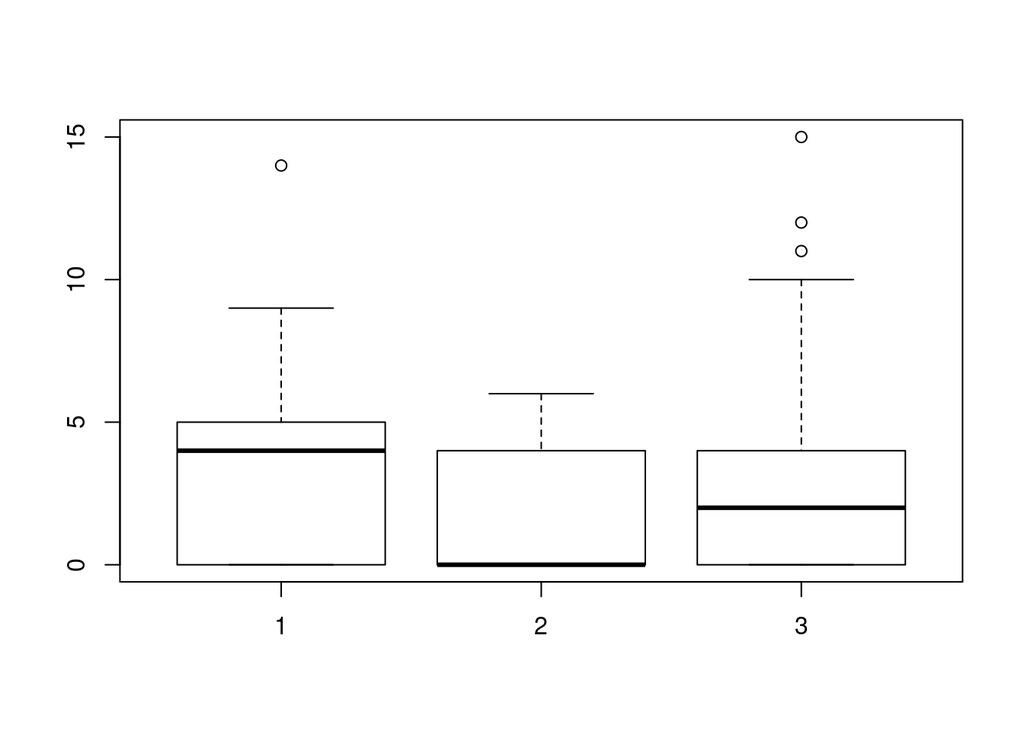

```
## $stats
##      [,1] [,2] [,3]
## [1,]    0    0    0
## [2,]    0    0    0
## [3,]    4    0    2
## [4,]    5    4    4
## [5,]    9    6   10
## attr(,"class")
##         1
## "integer"
##
## $n
## [1]  37  15 121
##
## $conf
##          [,1]      [,2]     [,3]
## [1,] 2.701248 -1.631817 1.425455
## [2,] 5.298752  1.631817 2.574545
##
## $out
## [1] 14 15 11 12
##
## $group
## [1] 1 3 3 3
##
## $names
## [1] "1" "2" "3"
```

```r
# Seems to showcase Preference for lighter colors (with outliers)
with(crab,(boxplot(n.sat~spine)))
```

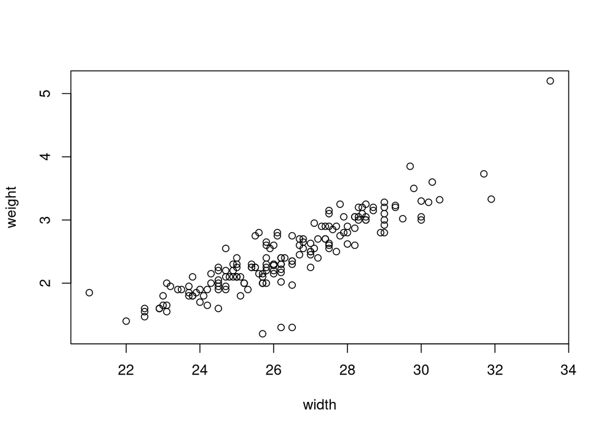

```r
with(crab,plot(width,weight)) #Here we see a tight correlation between width and height
```

We wanted to use a Poisson distribution to model the number of male satellites:

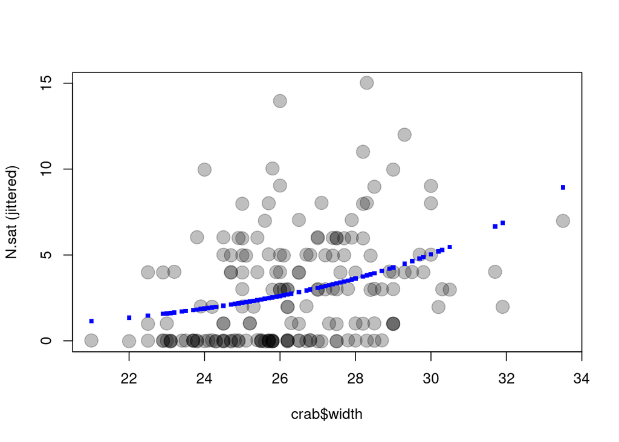

```r
model=glm(data=crab,n.sat~width,family=poisson())

plot(crab$width,jitter(crab$n.sat,0.2),cex=3,pch=20,col=rgb(0,0,0,1/4),ylab="N.sat (jittered)")
points(pch=".",cex=5,col="blue",crab$width,fitted.values(model))
```

## Overdispersion

The conditional distribution of $\textrm{n.sat}$ should be Poisson. Which means the variance for $\textrm{n.sat}$ for a given value of $\textrm{width}$ should be the same as the mean. We estimated this:

```r
approx=split(crab$n.sat,cut(crab$width,7))
#A key thing to look for in Poisson regression is "overdispersion"
# The idea is that in a Poisson regression the conditional distribution of Y shoudl be Poisson... this
# this means the variance should equal the mean.  Let's bin n.sat by width and see what we get:
sapply(approx,mean)
```

```
##   (21,22.8] (22.8,24.6] (24.6,26.4] (26.4,28.1] (28.1,29.9] (29.9,31.7]
##    1.000000    1.312500    2.711864    3.146341    4.666667    4.857143
## (31.7,33.5]
##    4.500000
```

```r
sapply(approx,var)
```

```
##   (21,22.8] (22.8,24.6] (24.6,26.4] (26.4,28.1] (28.1,29.9] (29.9,31.7]
##    3.000000    5.963710    9.587960    6.478049   16.076923    7.142857
## (31.7,33.5]
##   12.500000
```

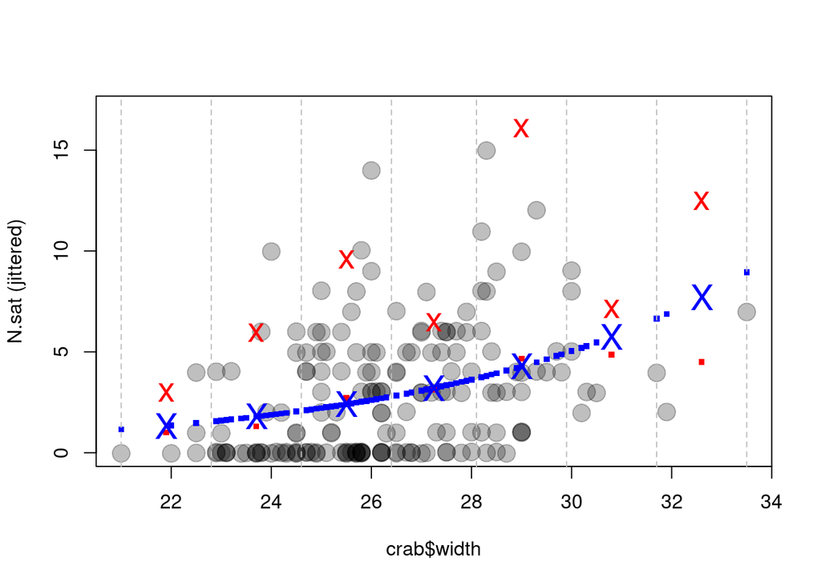

```r
obs.means=sapply(approx,mean)
obs.vars=sapply(approx,var)
predict=function(x){prod(exp(c(1,x)*coef(model)))}
Predict=Vectorize(predict)
plot(crab$width,jitter(crab$n.sat,0.2),cex=3,pch=20,col=rgb(0,0,0,1/4),ylim=c(0,17),ylab="N.sat (jittered)")
points(pch=".",cex=5,col="blue",crab$width,fitted.values(model)) #Fitted means
points(pch=".",cex=5,col="red",mids,obs.means) #Observed means
points(pch="x",cex=1.8,col="red",mids,obs.vars) #Observed vars
points(pch="X",cex=1.8,col="Blue",mids,Predict(mids)) #Analagous Fitted means

abline(v=union(lowers,uppers),lty=2,col="gray")
```

It wasn’t really what we had hoped for… so we tried a family of distributions with a higher variance

## Negative Binomial

A negative binomial situation is comprised of independent, dichotomous trials with constant probability of success, $p$. The number of failures before the $r$th success are counted.

Under this parameterization the formula is:

$$P(X=k) = {r+k-1}{k}p^r(1-p)^k$$

Note that the two parameter are the probability of success, $p$, and the number of succeses at which we stop counting, which is $r$. The language R calls $r$ the $\textrm{size}$.

Here’s a typical graph:

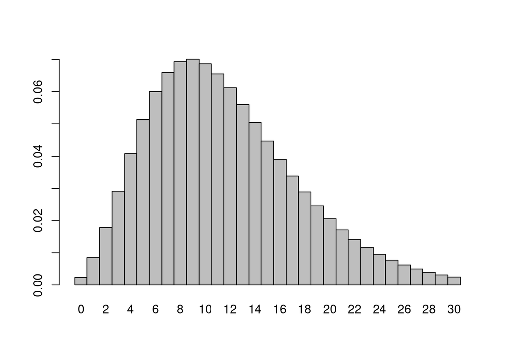

```r
barplot(dnbinom(0:30,5,0.3),width=1,space=0,names=0:30)
```

Note that $\frac{1}{1-p} \ge 1$ so the variance is higher than the expected value.

Two common alternate parameterizations use

*$\mu$ and $\alpha$* $\mu$ and $\textrm{size}$

The only differences between those two are $\alpha = \frac{1}{r}$. Sometimes $\alpha$ is called the $\textrm{shape}$ parameter. The key idea is that

$$\begin{aligned}
\mathbb{E}(X) &= \mu &\textrm{We specify the expected value}\\
\textrm{VAR}(X) &= \mu + \alpha \mu^2\\
&= \mu + \frac{1}{\textrm{r}}\mu^2
\end{aligned}$$

```r
library(MASS)
model.nb=glm.nb(data=crab,n.sat~width)
summary(model.nb)
```

```
##
## Call:
## glm.nb(formula = n.sat ~ width, data = crab, init.theta = 0.90456808,
##     link = log)
##
## Deviance Residuals:
##     Min       1Q   Median       3Q      Max
## -1.7798  -1.4110  -0.2502   0.4770   2.0177
##
## Coefficients:
##             Estimate Std. Error z value Pr(>|z|)
## (Intercept) -4.05251    1.17143  -3.459 0.000541 ***
## width        0.19207    0.04406   4.360  1.3e-05 ***
## ---
## Signif. codes:  0 '***' 0.001 '**' 0.01 '*' 0.05 '.' 0.1 ' ' 1
##
## (Dispersion parameter for Negative Binomial(0.9046) family taken to be 1)
##
##     Null deviance: 213.05  on 172  degrees of freedom
## Residual deviance: 195.81  on 171  degrees of freedom
## AIC: 757.29
##
## Number of Fisher Scoring iterations: 1
##
##
##               Theta:  0.905
##           Std. Err.:  0.161
##
##  2 x log-likelihood:  -751.291
```

Notice the dispersion paramter (they call it $\theta$)

Now let’s compare again:

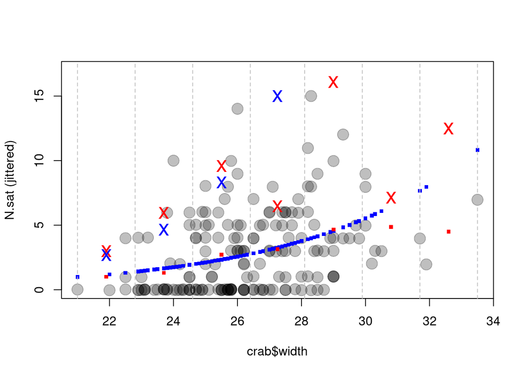

```r
mid.mus=sapply(mids,function(m){exp(sum(coef(model.nb)*c(1,m)))})
mid.vars=mid.mus+mid.mus^2/model.nb$theta

plot(crab$width,jitter(crab$n.sat,0.2),cex=3,pch=20,col=rgb(0,0,0,1/4),ylim=c(0,17),ylab="N.sat (jittered)")
points(pch=".",cex=5,col="blue",crab$width,fitted.values(model.nb)) #Fitted means
points(pch=".",cex=5,col="red",mids,obs.means) #Observed means
points(pch="x",cex=1.8,col="red",mids,obs.vars) #Observed vars

points(pch="x",cex=1.8,col="Blue",mids,mid.vars) #Analagous Fitted vars for NB

abline(v=union(lowers,uppers),lty=2,col="gray")
```

## R code used in class

```
barplot(dpois(0:10,3),space=0,width=1,names=0:10)
pois.lik=function(mu,k){exp(-mu)*mu^k/factorial(k)}
curve(pois.lik(x,3),0,10)
curve(dpois(3,x),0,10)
observed=rpois(10,3)
barplot(table(observed))
pois.lik(3,observed) #Likelihood of each observation

pois.lik2=function(mu,k){prod(exp(-mu)*mu^k/factorial(k))} #Fixed for multiple observations
Pois.lik2=Vectorize(pois.lik2,"mu") #Vectorized for graphing
curve(Pois.lik2(x,observed),0,10,ylab="Likelihood",xlab="Value of Mu")
curve(log(Pois.lik2(x,observed)),0,10,ylab="Likelihood",xlab="Value of Mu")

df <- read.csv("https://stats.idre.ucla.edu/stat/data/binary.csv")
glm(data=df,admit~gre,family=binomial())

# Everybody uses the crab data
crab=read.table("~/dsci3701/Lectures/Week 7/crab.txt")
crab=read.table("https://personal.psu.edu/abs12/stat504/online/07_poisson/graphics/crab.txt")
colnames(crab)=c("obs","color","spine","width","weight","n.sat")
crab=crab[,-1] #Drop the observation column
pairs(crab)
#Obs: Observation Number
#Color: 1: light medium
#       2: medium
#       3: dark medium
#       4: dark
#Spine Condition
#       1: Both good
#       2: One worn or broken
#       3: Both worn or broken
#Carapace Width (in cm)
#Weight in kilograms
#Number of Satellites (aka-- male's grouped around female hoping to mate)
#Data from Jane Brockmann, Zoology Department University of Floriday from Etcholog 102: 1-21, 1996
with(crab,{plot(table(color,spine))}) #Obvious relation... suggests age to me
#As color gets darker spine conditions gets worse
with(crab,plot(table(color,cut(width,5)))) #That's not consistent with age.. I would have thought
# carapace width was associated with age... but small
with(crab,boxplot(width~color))
```

[output cut: 65 more lines]

```
#Compare
mid.vars
sapply(approx,var)
sapply(approx,length)
# Much better on the low-end.  And cetainly a better fit on some of the bigger

# Back to logistic (Didn't get to thois in class)

crab$hasS = as.numeric(crab$n.sat>0)
model.logistic=glm(data=crab,hasS~width,family=binomial())
summary(model.logistic)
fv=fitted.values(model.logistic)
ov=crab$hasS
pv=as.numeric(fv>=0.5)
table(pv,ov)
```